# historical epidemiology of plague

1 December 2025

## plague: first pandemic

- *Yersinia pestis*
- causative agent of the *Black Death*
- Plague of Justinian (541) - approx. 750 (ancient DNA)

## Harbeck et al. (2013)

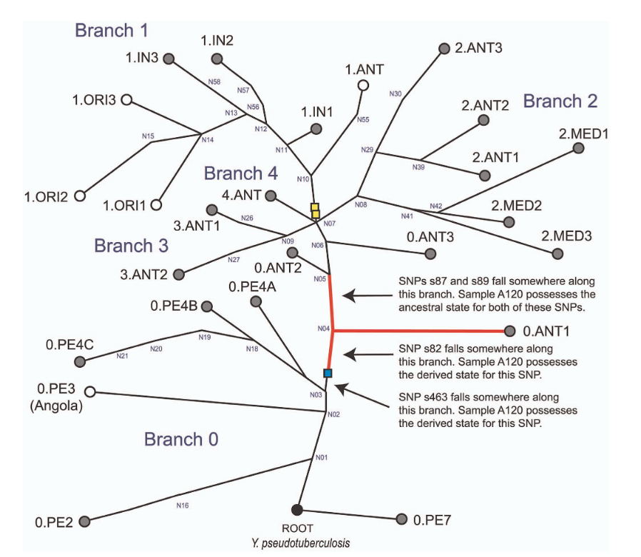

## second pandemic

- Black Death! 1347 onward
- human pop 450M → 350-375M by 1400
- continues until late 18th c.
- Shakespeare, Isaac Newton, etc. etc.
- also validated from ancient DNA

[figure not shown]

[Britannica](https://cdn.britannica.com/98/6698-004-B92A927B.gif)

## acceleration (Earn et al., 2020)

- get historical details on plague from wills, parish records, London Bills of Mortality …

[figure not shown]

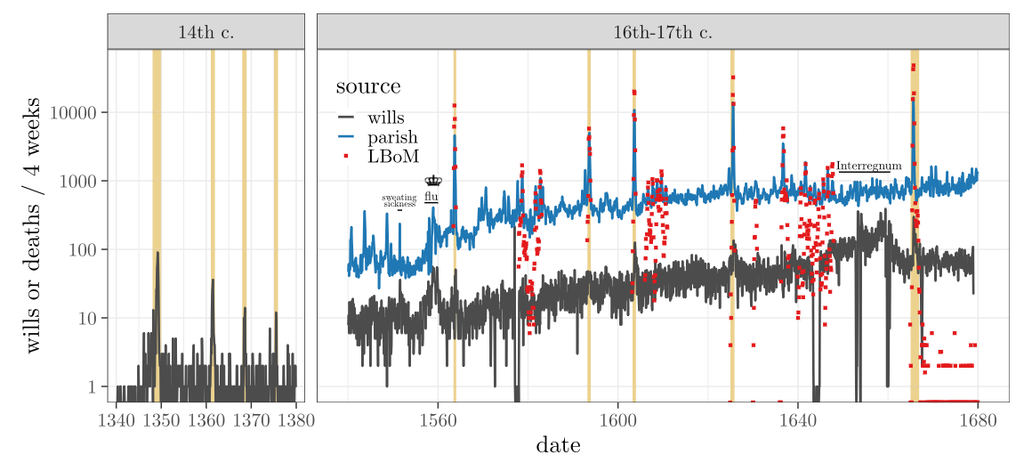

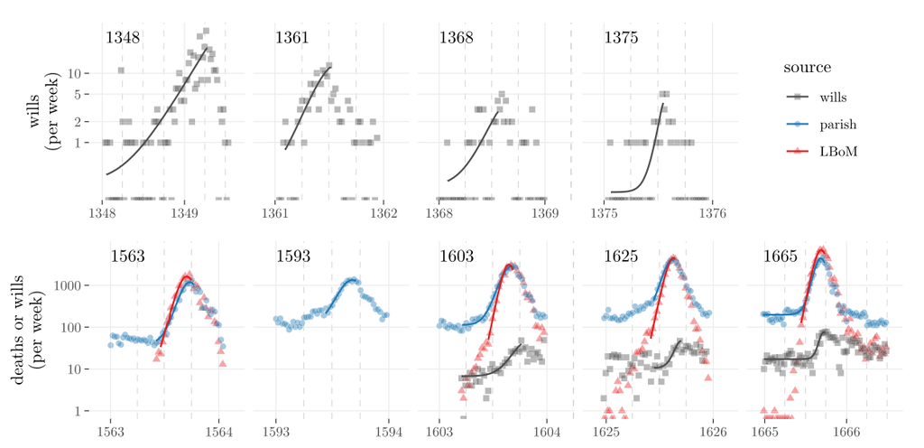

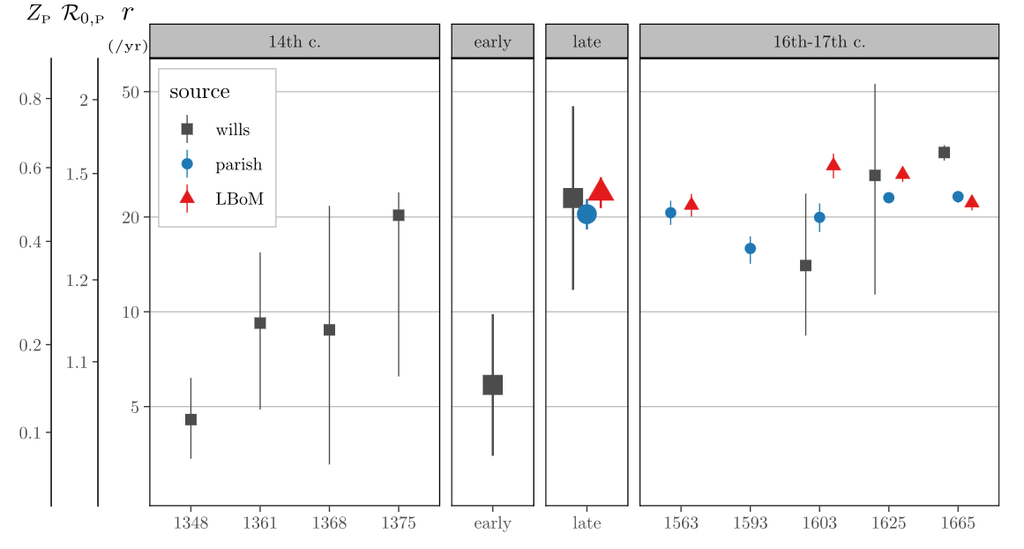

## *Y. pestis* transmission

- Classic story: rat-flea transmission, human spillover
- Possible *pneumonic* transmission

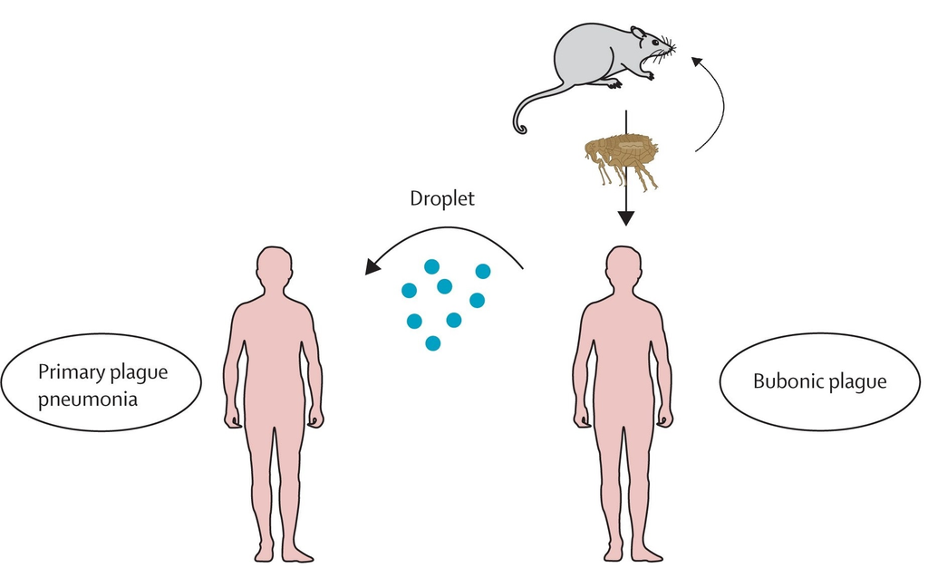

## Human-ectoparasite transmission

Human-to-human transmission via ectoparasites (e.g. lice)

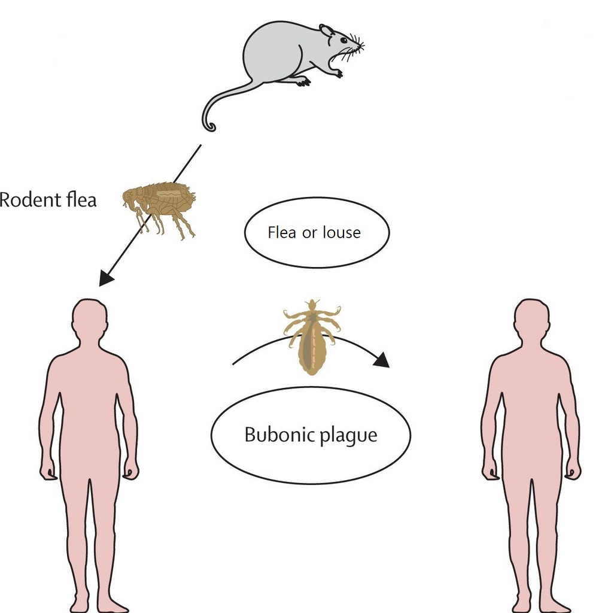

## data fits (Dean et al., 2018; Dean, 2019)

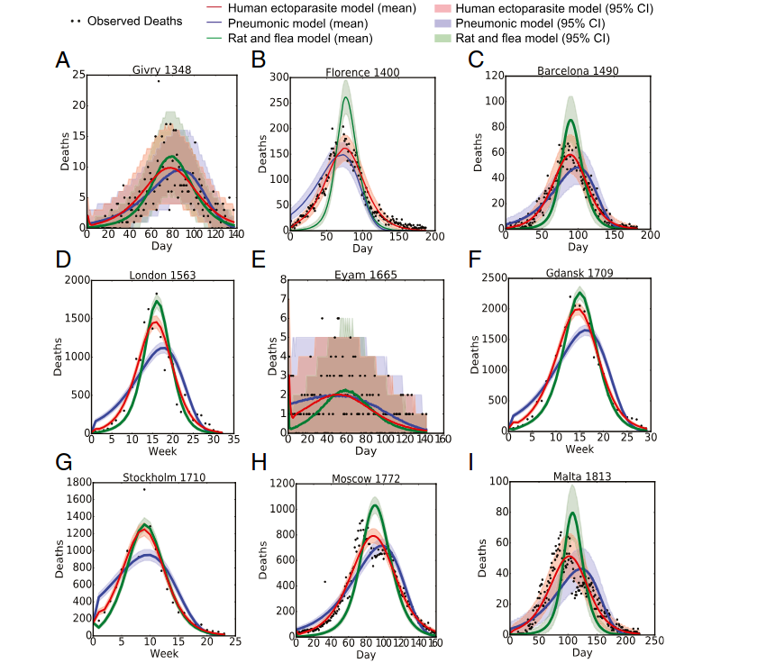

## combined model

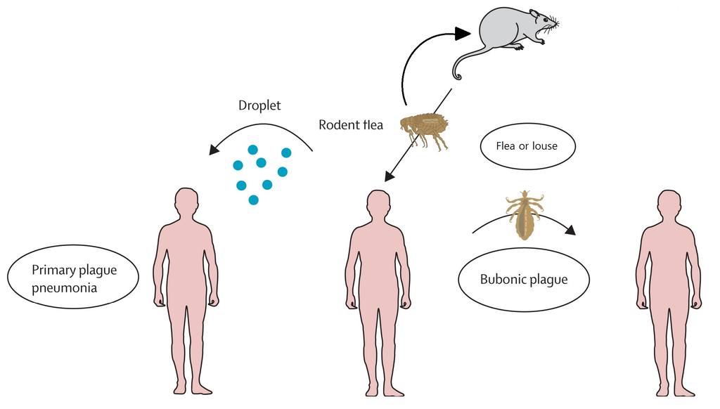

## box diagram

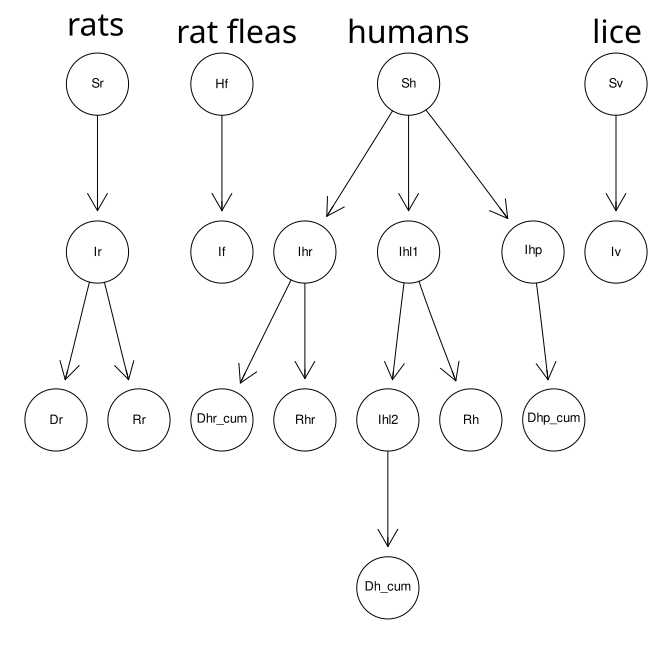

## priors

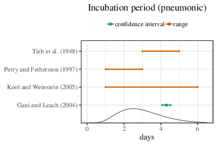

## results (example)

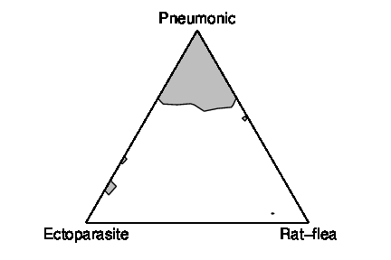

## results (all)

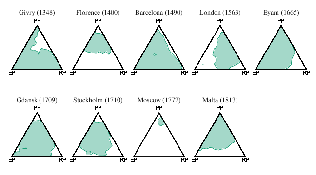

## virulence evolution

- Sidhu et al. (2025)
- repeated evolution of PLA (plasminogen activator) depletion across pandemics

## PLA results: first pandemic

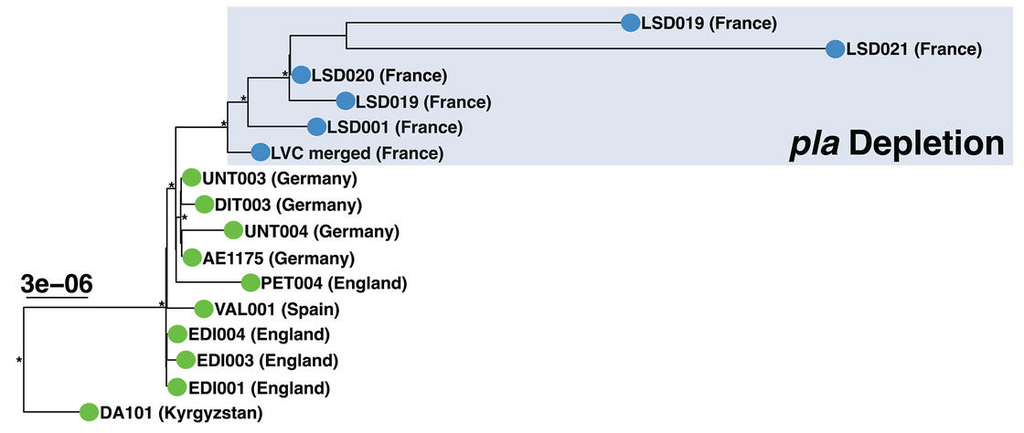

## second pandemic

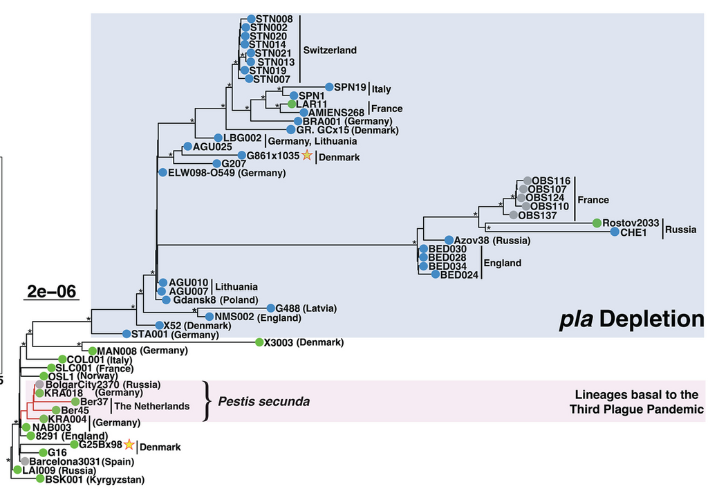

## third pandemic

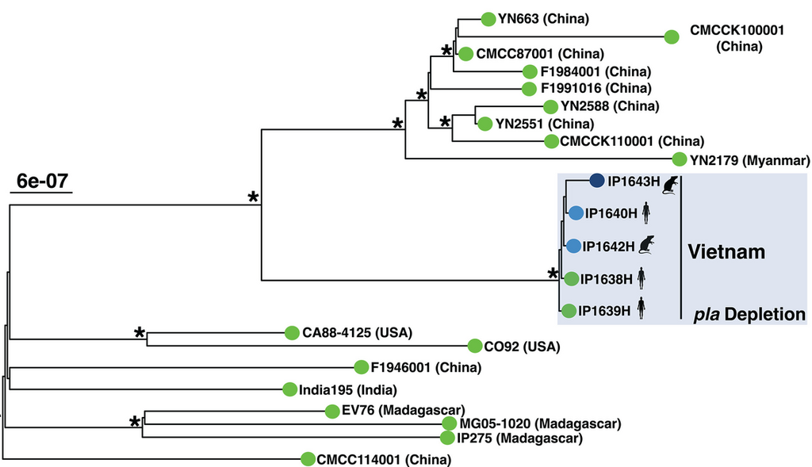

## PLA phenotypes

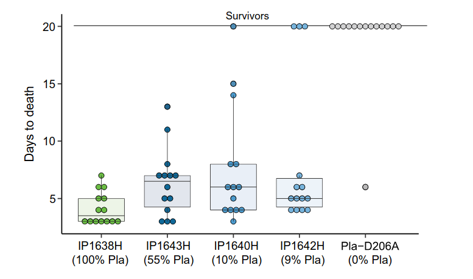

## evolutionary mechanisms?

- tradeoff theory *doesn’t work*
- most transmission is via fleas leaving dying rats
- ‘infectious period’ is a burst at the end of the infection
- how can PLA-depleted strains evolve (repeatedly)?

## burnout theory

Parsons et al. (2024)

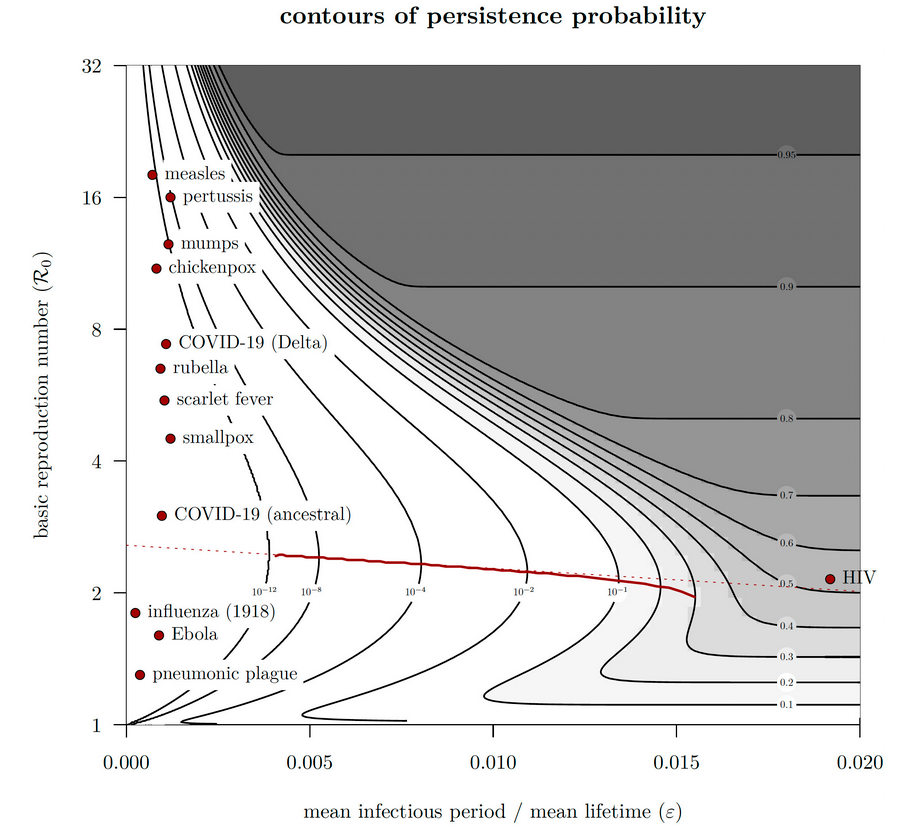

## metapopulation model

## metapopulation results

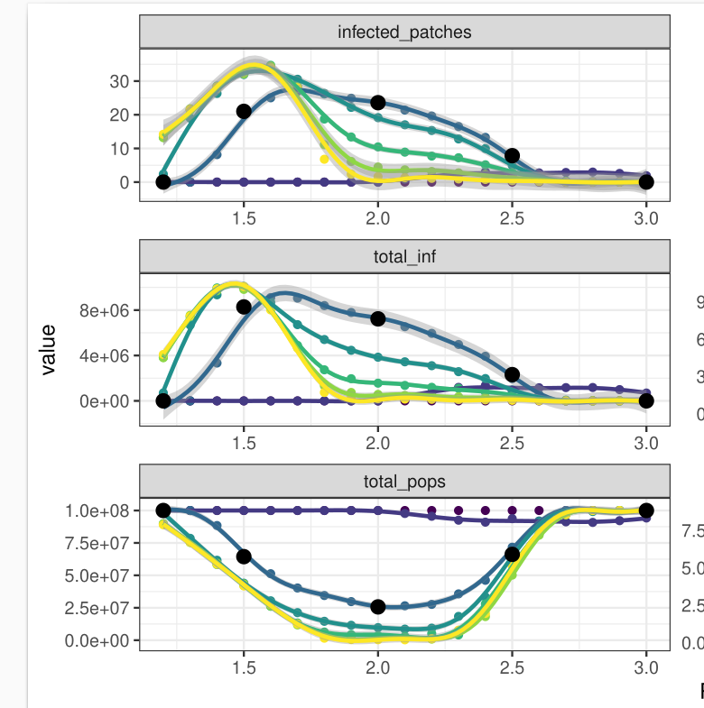

## References

Dean, K. R. (2019). *The epidemiology of plague in Europe: Inferring transmission dynamics from historical data* [Doctoral Thesis].

Dean, K. R., Krauer, F., Walløe, L., Lingjærde, O. C., Bramanti, B., Stenseth, N. C., & Schmid, B. V. (2018). Human ectoparasites and the spread of plague in Europe during the Second Pandemic. *Proceedings of the National Academy of Sciences*, 201715640. https://doi.org/10.1073/pnas.1715640115

Earn, D. J. D., Ma, J., Poinar, H., Dushoff, J., & Bolker, B. M. (2020). Acceleration of plague outbreaks in the second pandemic. *Proceedings of the National Academy of Sciences*, *117*(44), 27703–27711. https://doi.org/10.1073/pnas.2004904117

Harbeck, M., Seifert, L., Hänsch, S., Wagner, D. M., Birdsell, D., Parise, K. L., Wiechmann, I., Grupe, G., Thomas, A., Keim, P., Zöller, L., Bramanti, B., Riehm, J. M., & Scholz, H. C. (2013). Yersinia pestis DNA from Skeletal Remains from the 6th Century AD Reveals Insights into Justinianic Plague. *PLOS Pathogens*, *9*(5), e1003349. https://doi.org/10.1371/journal.ppat.1003349

Parsons, T. L., Bolker, B. M., Dushoff, J., & Earn, D. J. D. (2024). The probability of epidemic burnout in the stochastic SIR model with vital dynamics. *Proceedings of the National Academy of Sciences*, *121*(5), e2313708120. https://doi.org/10.1073/pnas.2313708120

Sidhu, R. K., Mas Fiol, G., Lê-Bury, P., Demeure, C. E., Bougit, E., Beau, R., Balière, C., Kwasiborski, A., Caro, V., Klunk, J., Salkeld, D. J., Carmichael, A., Varlık, N., Poinar, D., Earn, D. J. D., Bolker, B. M., Dushoff, J., Golding, G. B., Rascovan, N., … Poinar, H. N. (2025). Attenuation of virulence in *Yersinia pestis* across three plague pandemics. *Science*, *388*(6750), eadt3880. https://doi.org/10.1126/science.adt3880

Last updated: 2025-11-30 20:41:32.558256